# Resvaneundersökning i Region Uppsala

WSP Transportsystem

2021-10-01

# 1 Sammanfattning

## 1.1 Antal resor

Antalet resor per dygn i Region Uppsala uppgick till 651 429. I genomsnitt gjorde 67 procent åtminstone en resa per dag. Totalt transporterade de boende sig 10 391 179 kilometer under en genomsnittsdag summerat över samtliga färdmedel.

## 1.2 Färdmedelsfördelning

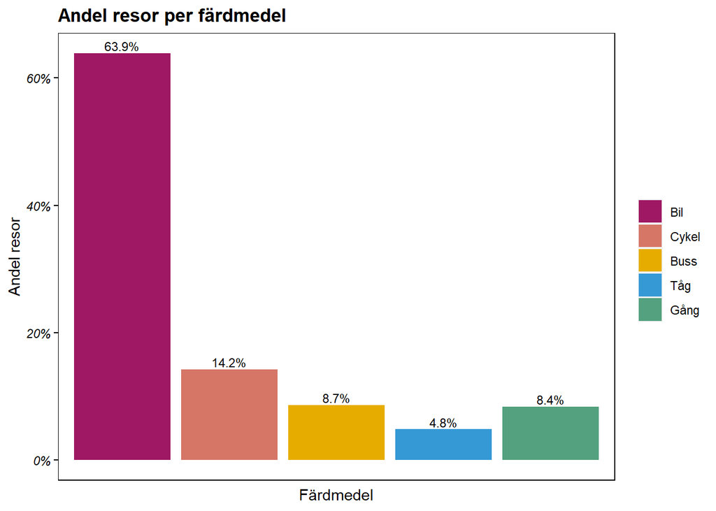

Figure 1.1: Resornas färdmedelsfördelning sett till antalet resor.

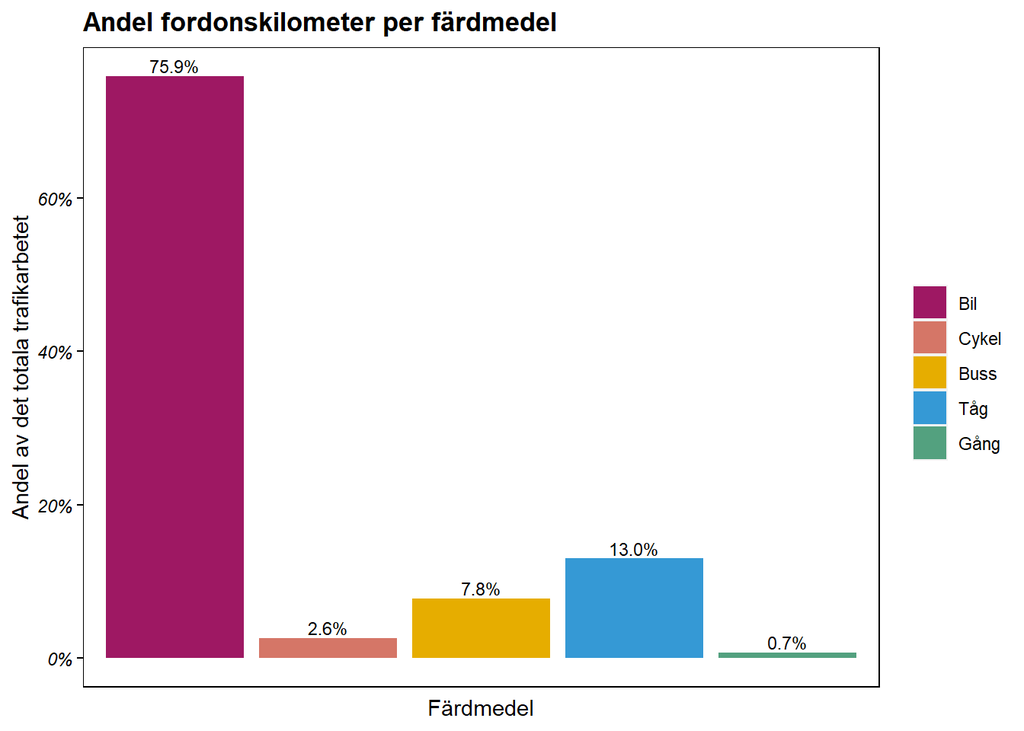

Figure 1.2: Resornas färdmedelsfördelning sett till antalet fordonskilometer.

## 1.3 Fördelning mellan män och kvinnor

Män och kvinnors resande skiljer sig åt. Män gjorde 2,1 resor per person och dag, medan kvinnor gjorde 2,0. Bland män stod bil för en större del av resorna (69 %) än bland kvinnor (63 %). För kvinnor var istället kollektivtrafik och cykel vanligare än bland män (14 respektive 13 % för kvinnor och 11 respektive 11 % för män).

## 1.5 Vanligaste reserelationer

Den vanligaste förekommande resan inom en kommun skedde inom Uppsala följt av Håbo. Mellan två kommuner var den vanligaste förekommande reserelationen mellan Knivsta–Uppsala följt av relationen Uppsala–Knivsta. När det gäller målpunkter utanför Region Uppsala, var den vanligaste tätorten Stockholm, vilket också var den vanligaste kommunen för utpendlingsresor.

# 2 Inledning

Följande resvanerapport har tagits fram för att öka kunskapen om dagens resmönster för olika trafikantgrupper i Region Uppsala. Rapportens resultat avser att ge en bild av hur resandet ser ut en genomsnittlig vardag 2021. Resultatet utgör ett viktigt underlag för att planera för en hållbar tillväxt och ett hållbart resande. Rapporten är skapad genom ett automatiserat skript, framtaget av WSP på uppdrag av Region Uppsala. Skriptet läser och sammanställer data från kollektivtrafikbarometern, samt presenterar och kommenterar resultaten i löpande text.

## 2.1 Metod

Rapporten är baserad på data från Svensk Kollektivtrafiks Kollektivtrafikbarometern[^1]. Kollektivtrafikbarometern är en branschgemensam nationell kvalitets- och resvaneundersökning som riktar sig till den svenska allmänheten mellan 15 och 85 år, både de som använder kollektivtrafiken och de som inte gör det. Till grunden av datainsamlingen ligger ett slumpmässigt och representativt individurval ur ett befolkningsregister utifrån postnummerområden.

Till skillnad från de flesta resvaneundersökningar utförs Kollektivtrafikbarometer kontinuerligt med dataleveranser varje månad. Fördelen med en kontinuerlig insamling är att säsongsvariationer utjämnas och enskilda händelser (tex mycket regn under insamlingsperioden) påverkar resultatet inte särskilt. Det är också möjligt i princip, dock inte med rapportverktyget, att följa trender över tid och analysera skillnader i resandet under olika årstider.

Datainsamlingen sker via en inbjudan som skickas via post till personer som ingår i urvalet. Bortfall, dvs personer med inbjudan som inte svarar, är ett viktigt kvalitetskriterium och är jämförbart med andra resvaneundersökningar. Kollektivtrafikbarometer använder sig dock av en speciell metod där en person som väljer att inte svara på enkäten ersätts genom utskick av inbjudan till en annan slumpmässigt vald person. Metoden säkerställer att beställaren får den beställda mängden besvarade enkäter. Jämförelse av fördelningen av kön och ålder bland personer som bevarar enkäten och befolkningen används för att bedöma om urvalet är representativt för befolkningen.

Inbjudan som skickas till valda personer innehåller en länk till en webbportal där personen får svara på frågor. Varje svarsperson får registrera upp till fem resor som gjordes dagen innan. För varje resa besvaras ett antal frågor som tillexempel resans ärende, färdmedel och var resan började och avslutades. Resans start och slut registreras av svarspersonen i en onlinekarta. Respektive koordinater extraheras och bifogas till datatabellen.

Hanteringen av Kollektivtrafikbarometerns rådata är automatiserad med hjälp av ett skript som är skrivet i programmeringsspråket R. I datahanteringen ingår kategorisering av resekoordinater, tex inom eller utanför en tätort, anonymisering som rensar bort personuppgifter ifall data ska delas utanför organisationen, och beräkning av reslängder med hjälp av Google directions API[^2].

Produktionen av RVU-rapporten sker också genom ett skript. Skriptet möjliggör rapporter på region, kommun och tätort nivå genom filtrering av data. Rapportens geografiska omfattning och tidsperiod definieras i indata till skriptet. Kollektivtrafiksbarometerns enkät, skript och andra bakgrundsdokument finns tillgängliga på programkodslagringsplattformen GitHub[^3].

Eftersom tabeller, grafer och löptext produceras av ett skript behöver rapporten läsas med försiktighet. Rapporten bör inte produceras på skralt underlag. Innan resultat lyfts ur sitt sammanhang i rapporten, bör de granskas kritiskt. Resultat som bygger på väldigt få respondenter bör inte tas som en allmän sanning.

## 2.2 Population och urval

Kollektivtrafiksbarometerns attityd- och resvaneundersökning är en årlig och nationell enkätundersökning som strävar efter att fånga ett representativt urval av befolkningen i respektive region. För varje respondent lagras egenskaper som kön, ålder och koordinater till hemmet. I denna rapport har resultaten sammanfattats uppdelade geografiskt på kommun.

I Tabell 2.1 återfinns befolkning, antal respondenter och andelen svarande av befolkningen. Andelen svarande ska ej förväxlas med svarsfrekvens (hur många av de tillfrågade som valde att svara på enkäten). Respondenternas kön och ålder per område finns redovisade i Tabell 2.2.

Table 2.1: Antal svar jämfört med befolkningen (15-85 år) i respektive område

| Område | Respondenter | Befolkning | Andel av befolkningen (%) |
| --- | --- | --- | --- |
| Enköping | 275 | 37 609 | 0,7 |
| Heby | 97 | 11 732 | 0,8 |
| Håbo | 1 038 | 17 618 | 5,9 |
| Knivsta | 123 | 14 627 | 0,8 |
| Tierp | 129 | 17 612 | 0,7 |
| Uppsala | 1 888 | 193 701 | 1,0 |
| Älvkarleby | 58 | 7 833 | 0,7 |
| Östhammar | 155 | 18 659 | 0,8 |
| Totalt | 3 763 | 319 391 | 1,2 |

Andelen svarande av befolkningen (15 år och äldre) var i genomsnitt 1 %. Högst andel svarande återfinns i Håbo, där andelen svarande var 6 %. Lägst andel svarande återfinns i Enköping, där andelen svarande var nära 1 %.

Table 2.2: Antal svar per kön och åldersgrupp

| Område | Respondenter | Man | Kvinnor | 15–24 år | 25–64 år | 65–85 år |
| --- | --- | --- | --- | --- | --- | --- |
| Enköping | 275 | 146 | 124 | 37 | 174 | 64 |
| Heby | 97 | 44 | 52 | 12 | 66 | 19 |
| Håbo | 1 038 | 507 | 529 | 64 | 604 | 370 |
| Knivsta | 123 | 55 | 60 | 21 | 82 | 20 |
| Tierp | 129 | 69 | 59 | 18 | 83 | 28 |
| Uppsala | 1 888 | 895 | 958 | 316 | 1 244 | 328 |
| Älvkarleby | 58 | 29 | 29 | 7 | 32 | 19 |
| Östhammar | 155 | 70 | 81 | 22 | 88 | 45 |
| Totalt | 3 763 | 1 815 | 1 892 | 497 | 2 373 | 893 |

Eftersom svarsbenägenheten varierar mellan olika grupper av invånare kan viss skevhet i representationen uppstå, trots att urvalet från början gjorts på ett representativt sätt. Genom att använda en mixad insamlingsmetod, där fysisk post, telefon och sms har använts för att nå respondenterna, har svarsunderlaget kunnat hålla en bättre representativitet än traditionella underskningar. Viktning mot kön, ålder och urvalsområde har därför inte ansetts vara nödvändig.

Notera antalet respondenter per område. För att säkra slutsatser ska kunna dras krävs minst 50 respondenter. I områden med mycket litet antal respondenter kan det vara problematiskt att dra genrerella slutsatser. Resultat för områden med få antal respondenter nedan i resultatavsnittet bör tas med försiktighet.

# 3 Resultat

Nedan presenteras en sammanställning av resultat från resvaneundersökningen.

## 3.1 Körkort och biltillgång

Valet att färdas med bil, buss eller cykel eller att promenera är beroende av en mängd faktorer, såsom transportsystemets utbud och standard, attityder och kunskap, restriktioner och vanor. Avgörande för färdmedelsvalet är körkortsinnehav och biltillgång.

I Region Uppsala hade 83 procent av respondenterna körkort och 84 procent tillgång till bil. Störst körkortsinnehav återfanns i Tierp, med 89 procent. Lägst var andelen med körkort i Knivsta, där andelen var nära 74 procent. De som hade tillgång till bil varierade mellan 76 och 94 procent. I Tabell 3.1 framgår körkortsinnehav och biltillgång för respektive område.

Table 3.1: Antal respondenter med körkort och biltillgång

| Område | Körkort (%) | Biltillgång (%) |
| --- | --- | --- |
| Enköping | 83 | 88 |
| Heby | 83 | 88 |
| Håbo | 88 | 92 |
| Knivsta | 74 | 93 |
| Tierp | 89 | 92 |
| Uppsala | 80 | 76 |
| Älvkarleby | 85 | 86 |
| Östhammar | 87 | 94 |
| Totalt | 83 | 84 |

## 3.2 Antal resor

En genomsnittlig dag gjorde 67 procent av personer 15-85 år bosatta i Region Uppsala åtminstone en resa och totalt genomfördes 651 429 resor. Det motsvarar 2 resor per person och dag. I Tabell 3.2 framgår andel personer som rest och deras antal resor per dag redovisat per kön och ålderskategori.

Andelen som rest bland män och kvinnor var i samma storleksordning. Bland de som reser var dessutom antalet resor per dag snarlikt mellan kvinnor och män. I åldersgruppen 15–24 år var andelen som rest 72 procent, vilket är mer än övriga åldersgrupper.

Table 3.2: Antal resor per dag och resenärsgrupp

| Grupp | Andel personer som rest (%) | Resor per dag och person | Resor per dag och person (enbart de som rest) | Befolkning | Antal resor |
| --- | --- | --- | --- | --- | --- |
| **Kön** |  |  |  |  |  |
| Kvinna | 66 | 2,0 | 3,1 | 160 403 | 322 502 |
| Man | 68 | 2,1 | 3,0 | 158 988 | 327 174 |
| **Ålder** |  |  |  |  |  |
| 15–24 år | 72 | 2,1 | 3,0 | 71 214 | 151 025 |
| 25–64 år | 71 | 2,2 | 3,1 | 194 046 | 423 091 |
| 65–85 år | 54 | 1,6 | 3,0 | 56 466 | 91 496 |
| **Totalt** |  |  |  |  |  |
| Alla | 67 | 2,0 | 3,0 | 319 391 | 651 429 |

## 3.3 Resornas fördelning på färdsätt

I Figur 3.1 framgår att bil är det vanligaste färdmedlet i Region Uppsala och står för 66 procent av alla resor. Detta är också det vanligaste färdmedlet i varje enskild kommun.Högst andel återfanns i Håbo, med 85 %. Lägst var andelen i Uppsala, där endast 53 % av resorna gjordes med bil.

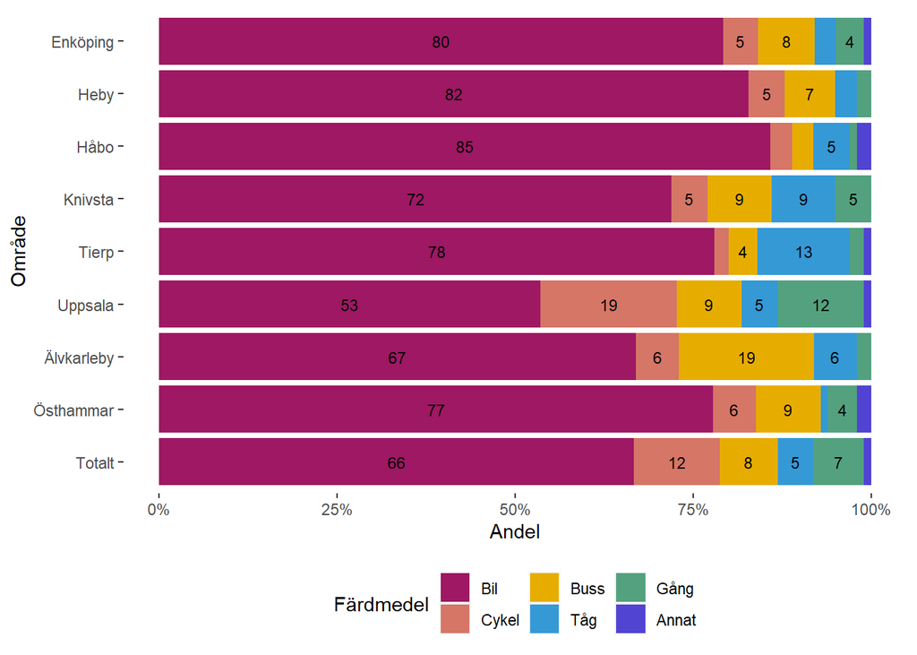

Figure 3.1: Resornas färdmedelsfördelning per område.

## 3.4 Bakgrundfrågor

Nedan följer sammanställningar kopplade till respondenternas egenskaper.

### 3.4.1 Färdsätt efter kön

I Figur 3.2 visas färdmedelsandelar per kön. Andelen män och kvinnor i undersökningen är 49 respektive 51 procent. Hur de reser brukar skilja sig åt. Bland män stod bil för en större del av resorna än bland kvinnor. För kvinnor var istället kollektivtrafik och cykel vanligare än bland män.

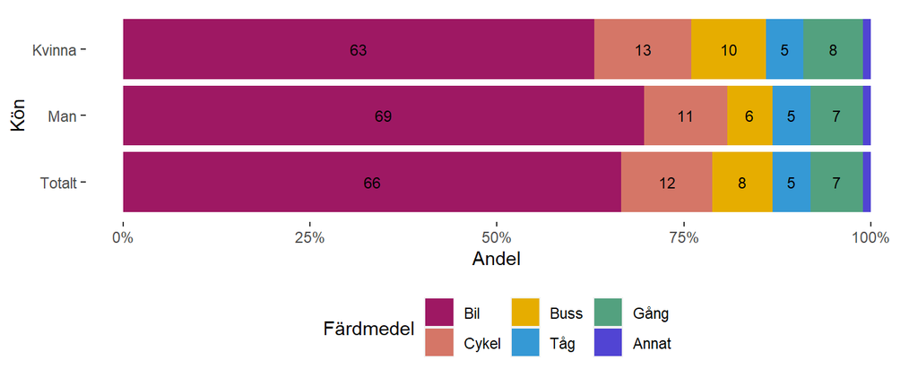

Figure 3.2: Resornas färdmedelsfördelning per kön.

### 3.4.2 Färdsätt efter ålder

Åldersgruppen 15–24 år utgjorde 22 procent, gruppen 25–64 år 60 procent och gruppen 65–85 år 18 procent av den undersökta befolkningen. I Figur 3.3 nedan jämförs färdmedelsandelar mellan olika åldersgrupper.

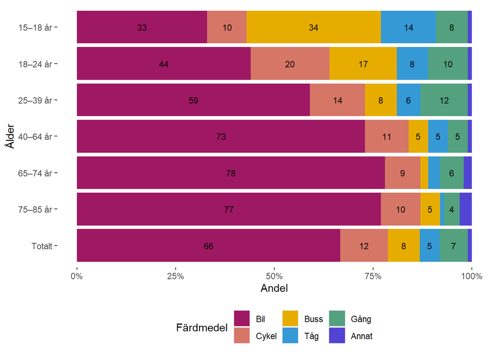

Figure 3.3: Resornas färdmedelsfördelning per åldersgrupp.

De yngsta åkte i högre utsträckning med kollektivtrafiken än övriga grupper. Däremot var det åldersgruppen 18–24 år som gjorde en större andel cykelresor än övriga grupper. Andelen bilresor var högst i ålderskategorin 65–74 år, där 78 procent av resorna gjordes med bil.

### 3.4.3 Färdsätt efter sysselsättning

I åldern 15–85 år var 61 procent förvärvsarbetande, 12 procent studerande, 19 procent var pensionärer. I Figur 3.4 nedan presenteras färdmedelsfördelningen per sysselsättningsgrupp. Bil var det vanligaste färdmedlet för samtliga grupper. Bil användes i störst utsträckning av gruppen *pensionär* och minst i gruppen *studerande*. Kollektivtrafiksandelen var högst i gruppen *studerande*. Störst andel cykelresor stod gruppen *studerande* för.

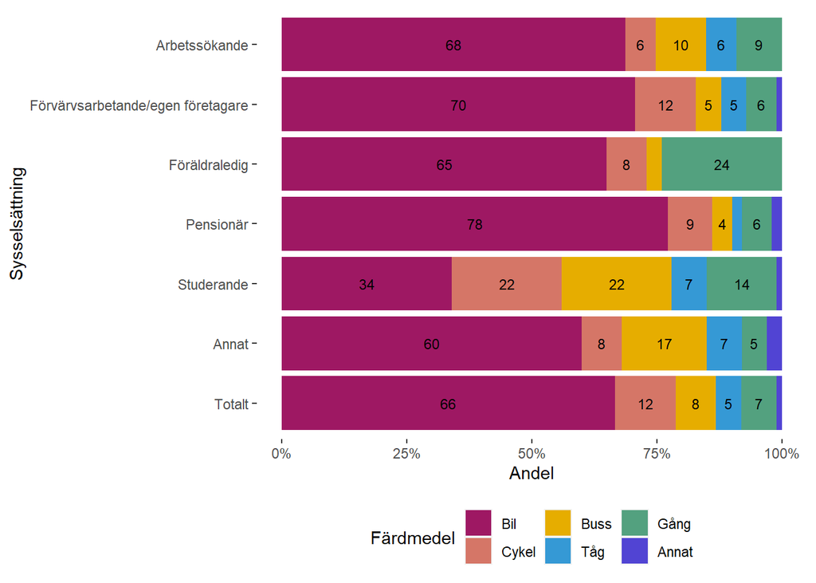

Figure 3.4: Resornas färdmedelsfördelning per sysselsättning

### 3.4.4 Färdsätt efter ärende

Resans *ärende* är syftet med resan och kan bland annat vara *inköp av dagligvaror* eller *arbete*. Kategorierna är valda för att alla typer av resor ska kunna falla in under en kategori. Ifall inget passande ärende finns, kan respondenten välja *annat ärende*. 3 procent av resorna har blivit kategoriserade som *annat ärende*.

Resor till bostaden utgör normalt sett en stor del av alla resor. I denna mätning var andelen resor till bostaden 40 procent, medan andelen arbetsresor var 17 procent. Av resor till arbetet var 59 procent bilresor, 21 procent kollektivtrafiksresor och 15 procent cykelresor.

I Figur 3.5 presenteras färdmedelsandelar för respektive ärendetyp. Bil valdes i störst utsträckning för ärendet *skjutsa/följa/hämta annan person* (91 %). För ärende *studier (till skola/studier)* användes dock bil i lägst utsträckning (20 %). Istället gjordes dessa resor i större utsträckning med kollektivtrafik (44 %).

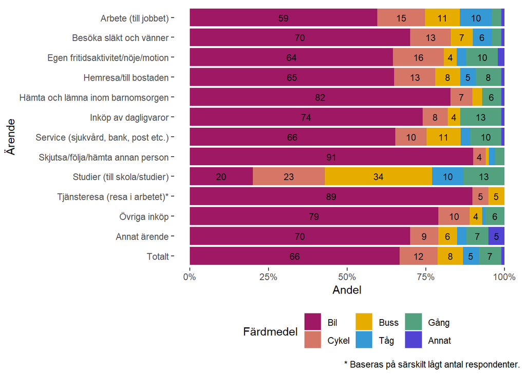

Figure 3.5: Resornas färdmedelsfördelning per ärende

## 3.5 Reslängd och fordonskilometer

I Tabell 3.3 framgår median, medelvärde, samt totalt antal fordonskilometer per färdmedel. I Tabell 3.4 framgår samma nyckeltal för respektive område. I tabellerna exkluderas resor som saknar angivna start- och slutkoordinater, samt de som saknar specifikation om färdmedel. I de fall underlaget är färre än 5 respondenter, utelämnas resultatet.

Table 3.3: Reslängd per resa och totalt antal fordonskilometer per färdmedel

| Färdmedel | Median | Medel | Totalt antal resor | Totalt antal fordonskilometer | Antal observationer |
| --- | --- | --- | --- | --- | --- |
| Bil | 14 | 27 | 290 200 | 7 887 483 | 3 302 |
| Cykel | 3 | 4 | 64 700 | 270 680 | 620 |
| Buss | 12 | 21 | 39 300 | 808 594 | 377 |
| Gång | 1 | 2 | 38 100 | 75 229 | 357 |
| Tåg | 58 | 62 | 21 900 | 1 349 193 | 241 |

I Region Uppsala var en typisk resa (medianen av alla resor) 9 kilometer lång. Längst var resorna med tåg, med en typresa på 58 kilometer. Kortast var resorna med gång, med en typresa på 1 km.

Bil var det vanligaste färdmedlet med 7 887 483 fordonskilometer, vilket motsvarar 76 % av det totala antalet fordonskilometrar för samtliga trafikslag för boende i Region Uppsala.

För boende i Uppsala var en typisk resa särskilt kort (7 km). De längsta resorna återfanns i Tierp, med en typresa på 35 kilometer. I Uppsala gjordes den största sammanlagda förflyttningen med 5424225 fordonskilometer, medan Älvkarleby stod för det minsta antalet fordonskilometer (264381 km)

Table 3.4: Reslängd per resa och totalt antal fordonskilometer per område.

| Område | Median | Medel | Totalt antal resor | Totalt antal fordonskilometer | Antal observationer |
| --- | --- | --- | --- | --- | --- |
| Enköping | 15 | 26 | 57 500 | 1 490 520 | 407 |
| Heby | 22 | 35 | 14 900 | 520 972 | 121 |
| Håbo | 20 | 29 | 19 900 | 573 925 | 1 126 |
| Knivsta | 17 | 21 | 24 900 | 524 218 | 208 |
| Tierp | 35 | 47 | 21 500 | 1 016 985 | 145 |
| Uppsala | 7 | 19 | 283 400 | 5 424 225 | 2 650 |
| Älvkarleby | 18 | 32 | 8 400 | 264 381 | 62 |
| Östhammar | 17 | 25 | 23 600 | 595 879 | 178 |

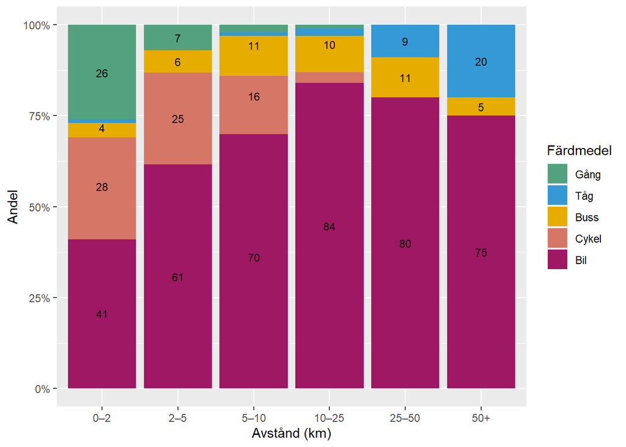

Figure 3.6: Resornas färdmedelsfördelning per avståndsklass.

### 3.5.2 Utpendling från Region Uppsala

Av alla resor som utgår från Region Uppsala, görs 12 procent till andra områden. Nedan sammanställs utpendlingen för boende i Region Uppsala uttryckt som andelar av resorna som startar i Region Uppsala. I Figur 3.7 redovisas utpendlingen till andra tätorter och i Figur 3.8 till andra kommuner. Den vanligaste tätorten för utpendlingsresor var Stockholm, vilket också var den vanligaste kommunen för utpendlingsresor. Anledningen till att inte inpendling kan redovisas är att urvalet ur resvaneundersökningen enbart omfattar boende i Region Uppsala.

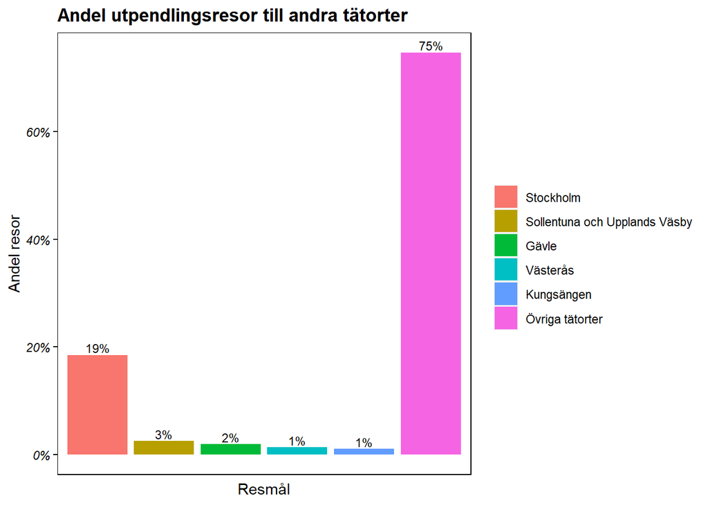

Figure 3.7: Andel utpendlingsresor från Region Uppsala till andra tätorter.

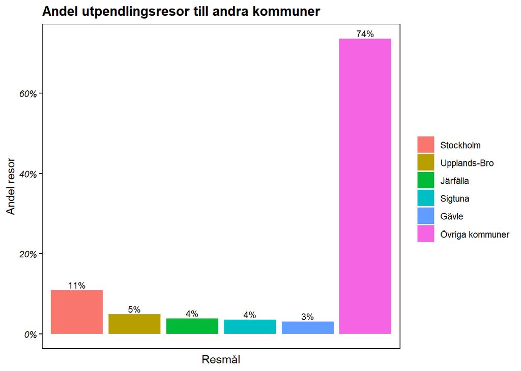

Figure 3.8: Andel utpendlingsresor från Region Uppsala till andra kommuner.

# 4 Bilagor

## 4.1 Karta

Nedan följer en karta över de kommuner som Region Uppsala inbegriper.

[figure not shown]

Karta över alla områden i rapporten.

## 4.2 Detaljerade tabeller

Nedan följer tabeller som avser att ge en mer detaljerad bild av resvaneundersökningen.

Table 4.1: Färdmedel per åldersgrupp, redovisat uppräknat på antalet invånare.

| Ålder | Bil | Cykel | Buss | Tåg | Gång | Annat | Totalt |
| --- | --- | --- | --- | --- | --- | --- | --- |
| 15–18 år | 7 196 | 2 249 | 7 496 | 2 998 | 1 649 | 150 | 21 739 |
| 18–24 år | 21 740 | 9 841 | 8 231 | 3 847 | 5 189 | 626 | 49 475 |
| 25–39 år | 49 625 | 11 902 | 7 089 | 4 748 | 10 081 | 1 171 | 84 616 |
| 40–64 år | 80 408 | 11 828 | 5 665 | 5 268 | 5 268 | 994 | 109 430 |
| 65–74 år | 30 017 | 3 610 | 950 | 1 140 | 2 280 | 633 | 38 630 |
| 75–85 år | 13 728 | 1 754 | 952 | 150 | 802 | 451 | 17 836 |
| Totalt | 211 403 | 39 437 | 24 664 | 16 257 | 23 613 | 4 018 | 319 391 |

Table 4.2: Färdmedel per åldersgrupp, redovisat i andelar uttryckt i procent.

| Ålder | Bil | Cykel | Buss | Tåg | Gång | Annat |
| --- | --- | --- | --- | --- | --- | --- |
| 15–18 år | 33% | 10% | 34% | 14% | 8% | 1% |
| 18–24 år | 44% | 20% | 17% | 8% | 10% | 1% |
| 25–39 år | 59% | 14% | 8% | 6% | 12% | 1% |
| 40–64 år | 73% | 11% | 5% | 5% | 5% | 1% |
| 65–74 år | 78% | 9% | 2% | 3% | 6% | 2% |
| 75–85 år | 77% | 10% | 5% | 1% | 4% | 3% |
| Totalt | 66% | 12% | 8% | 5% | 7% | 1% |

Table 4.3: Färdmedel per kön, redovisat uppräknat på antalet invånare.

| Kön | Bil | Cykel | Buss | Tåg | Gång | Annat | Totalt |
| --- | --- | --- | --- | --- | --- | --- | --- |
| Kvinna | 100 322 | 21 587 | 15 410 | 7 736 | 13 538 | 1 809 | 160 403 |
| Man | 110 357 | 17 990 | 9 281 | 8 582 | 10 489 | 2 289 | 158 988 |
| Totalt | 211 403 | 39 437 | 24 664 | 16 257 | 23 613 | 4 018 | 319 391 |

Table 4.4: Färdmedel per kön, redovisat i andelar uttryckt i procent.

| Kön | Bil | Cykel | Buss | Tåg | Gång | Annat |
| --- | --- | --- | --- | --- | --- | --- |
| Kvinna | 63% | 13% | 10% | 5% | 8% | 1% |
| Man | 69% | 11% | 6% | 5% | 7% | 1% |
| Totalt | 66% | 12% | 8% | 5% | 7% | 1% |

Table 4.5: Färdmedelsandelar per område, redovisat uppräknat på antalet invånare.

| Område | Bil | Cykel | Buss | Tåg | Gång | Annat | Totalt |
| --- | --- | --- | --- | --- | --- | --- | --- |
| Enköping | 30 051 | 1 979 | 2 879 | 990 | 1 440 | 270 | 37 609 |
| Heby | 9 634 | 572 | 858 | 382 | 286 | 0 | 11 732 |
| Håbo | 14 908 | 583 | 597 | 947 | 204 | 379 | 17 618 |
| Knivsta | 10 587 | 697 | 1 323 | 1 323 | 697 | 0 | 14 627 |
| Tierp | 13 686 | 424 | 743 | 2 228 | 424 | 106 | 17 612 |
| Uppsala | 103 484 | 37 707 | 18 225 | 9 497 | 22 694 | 2 095 | 193 701 |
| Älvkarleby | 5 222 | 497 | 1 492 | 497 | 124 | 0 | 7 833 |
| Östhammar | 14 360 | 1 098 | 1 646 | 274 | 823 | 457 | 18 659 |
| Totalt | 211 403 | 39 437 | 24 664 | 16 257 | 23 613 | 4 018 | 319 391 |

Table 4.6: Antal resor per färdmedel och område, redovisat i andelar uttryckt i procent.

| Område | Bil | Cykel | Buss | Tåg | Gång | Annat |
| --- | --- | --- | --- | --- | --- | --- |
| Enköping | 80% | 5% | 8% | 3% | 4% | 1% |
| Heby | 82% | 5% | 7% | 3% | 2% | 0% |
| Håbo | 85% | 3% | 3% | 5% | 1% | 2% |
| Knivsta | 72% | 5% | 9% | 9% | 5% | 0% |
| Tierp | 78% | 2% | 4% | 13% | 2% | 1% |
| Uppsala | 53% | 19% | 9% | 5% | 12% | 1% |
| Älvkarleby | 67% | 6% | 19% | 6% | 2% | 0% |
| Östhammar | 77% | 6% | 9% | 1% | 4% | 2% |
| Totalt | 66% | 12% | 8% | 5% | 7% | 1% |

[^1]: https://www.svenskkollektivtrafik.se/verktyg-och-system/kollektivtrafikbarometern/
[^2]: https://developers.google.com/maps/documentation/directions/overview
[^3]: https://github.com/bjornsh/kollektivtrafikbarometer